# Election Survey analysis proposal

For this analysis, I retried 4271 records of American adults surveyed before and after the 2016 election. I demonstrated separability of the data among several interesting dimensions. Moving forward, we should be able to examine how that separability relates to regional differences in voting patterns.

I calculated the principle components across all the dataset. Principle components analysis is a common dimension reduction technique intended to reduce the dimensionality of the data by rotating the data across the axes of the data that explain the most variance.

After finding the principle components, rather than selecting the components that explained the absolute most variance in the dataset, I selected components that were most predictive of the respondents’ voting records. To simplify the analysis, I selected only people who had voted and who had voted for either Hillary Clinton or Donald Trump.

The graph shows the distribution of respondents’ ten most predictive principle components. Some components, on their own, very clearly separate the voters for each candidate..

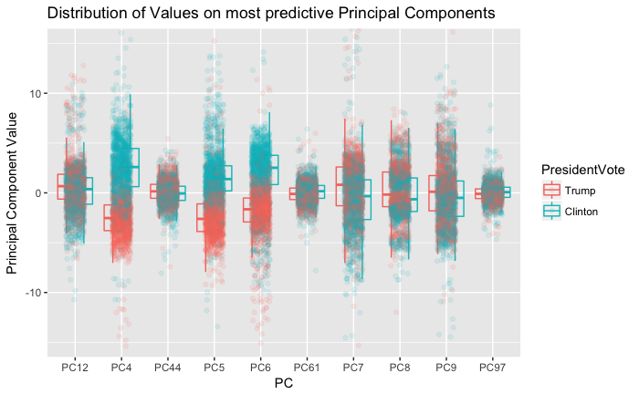

|  | Principle Component Question Text Sample |
| --- | --- |
| PC4 | Strength favor 2010 health care law; TV PROG Al Punto; Strength favor 2010 health care law; Working TLO now - work for self; Strength favor 2010 health care law; Days in week watch/listen/read news on… |
| PC5 | Radio PROG All Things Considered (NPR); TV PROG Al Rojo Vivo; SUMMARY - Build wall with Mexico; Working TLO now - work for govt; Force to solve international problems; Approval of Congress handling it… |
| PC6 | Radio PROG Fresh Air (NPR); TV PROG Aqui y Ahora; How important to speak English in US; Working TLO now - how many hours R works; Sending troops to fight ISIS; SUMMARY - Approval/disapproval Congress … |
| PC7 | Website CNN.com; TV PROG Despierta America; SUMMARY - Services to same sex couples; Working TLO now - hours works OK; SUMMARY - send troops to fight ISIS; 7pt scale liberal conservative - Rep Pres can… |
| PC44 | Website Huffington Post (www.huffingtonpost.com); TV PROG El Gordo y La Flaca; SUMMARY - Transgender policy; Working TLO now: worry about losing job in near future; Who in HH belongs to labor union; 7… |
| PC12 | Website Buzzfeed.com; TV PROG Hoy; STD Abortion: self-placement; Working now: out of work or laid off in last 6 mos; Internet use at home; How strongly does R feel that voting is a duty; Website Buzzf… |
| PC8 | PRE FTF CASI/WEB: Mention New York Times (nytimes.com); TV PROG Lo Mejor de Caso Cerrado; SUMMARY - Favor or oppose death penalty; Working now: had reduction in work hrs or pay cut; Does R have unexpi… |
| PC61 | Website Washington Post (washingtonpost.com); TV PROG Noticiero Telemundo; Ever think of self as part of church or denomination; www.usatoday.com (USA; Does R have other govt ID; PRE FTF CASI/WEB: Pre… |
| PC9 | Website BBC News (news.bbc.co.uk); TV PROG Noticiero Univision; POST: SUMMARY- Barack Obama is/isn't Muslim; online.wsj.com (Wall Street Journal); POST: How much U.S. support Israel in conflict w/Pale… |
| PC97 | Website The Guardian (theguardian.com); TV PROG Primer Impacto; POST: CSES: 10pt scale: like-dislike Democratic Pres cand; www.washingtonpost.com (Washington Post); POST: How much U.S. support Palesti… |

```
Call:
glm(formula = (PresidentVote == "Trump") ~ PC4 + PC5 + PC6 +
    PC7 + PC44 + PC12 + PC8 + PC61 + PC9 + PC97, family = binomial(link = "logit"),
    data = AllPCs.ClintonTrump)

Deviance Residuals:
    Min       1Q   Median       3Q      Max
-3.2349  -0.1487  -0.0225   0.1374   3.3582

Coefficients:
            Estimate Std. Error z value Pr(>|z|)
(Intercept) -0.37286    0.09501  -3.924 8.70e-05 ***
PC4         -0.62641    0.03443 -18.195  < 2e-16 ***
PC5         -0.63632    0.03815 -16.678  < 2e-16 ***
PC6         -0.59045    0.03828 -15.423  < 2e-16 ***
PC7          0.21052    0.03101   6.790 1.12e-11 ***
PC44         0.45675    0.07607   6.004 1.92e-09 ***
PC12         0.18862    0.04000   4.715 2.41e-06 ***
PC8          0.12118    0.03374   3.591 0.000329 ***
PC61        -0.21030    0.07742  -2.716 0.006599 **
PC9          0.15333    0.03055   5.019 5.20e-07 ***
PC97        -0.32781    0.10066  -3.256 0.001128 **
---
Signif. codes:  0 ‘***’ 0.001 ‘**’ 0.01 ‘*’ 0.05 ‘.’ 0.1 ‘ ’ 1

(Dispersion parameter for binomial family taken to be 1)

    Null deviance: 3416.3  on 2467  degrees of freedom
Residual deviance:  791.3  on 2457  degrees of freedom
AIC: 813.3

Number of Fisher Scoring iterations: 7
```

We can then move forward to examine the data in a nationwide map. Here, we can see how PC4, PC5, and PC6 are distributed across the US.

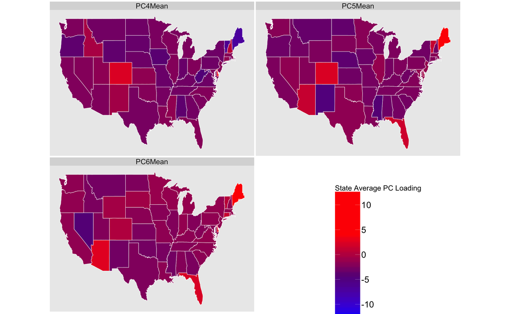

```r
ggplot(data=states_data)+
  geom_polygon(aes(x = long, y = lat, fill = `State Average PC Loading`,group=group), color = "white") +
   coord_fixed(1.7) +
  scale_fill_gradientn(colours=c("blue","#660088","red","red"))+
  ditch_the_axes+facet_wrap(~PC,nrow=2)+theme(strip.text=element_text(size=25),
                                              legend.position = c(0.8,0.2),
                                              legend.key.size = unit(6,"lines"),
                                              legend.title = element_text(size=25),
                                              legend.text = element_text(size=30))
```

## Discussion

From the work here, we can already see that states seprate out into distinct patterns. For instance, Florida and Maine, typically purple states, sit on one end of the spectrum of two principle components concerned with immigration.